# Communicating Findings: App Store Dataset

## Investigation Overview

This Dataset caught my attention because I’ve been a big fan of Apple Software Solutions and IOS for the past years, I deliberately download many apps from the App Store on my phone or laptop, and I want to have a better understanding & overview of the App Store in regarding the following:

- **Q1** What is the Quantity of **Free** & **Paid** Apps ? What is the Percentage of Each ?
- **Q2** What are the Top 10 Genres according to number of Apps Developed ?
- **Q3** What are the Least 10 Genres according to number of Apps Developed ?
- **Q4** What Genres are most Rated ?
- **Q5** What are the all-time Favorite Apps?
- **Q6** What are the current Favorite Apps?
- **Q7** What are the most successful apps according to revenue?
- **Q8** What is the Percentage of Free & Paid Apps in Each Popular Genre?
- **Q9** Do Paid apps receive better Rating than Free Apps ?
- **Q10** Is there any type of Correlation/Relationship between any Variables/Features?
- **Q11** Does The Size of an App has an effect on the price ?

## Dataset Overview

In the following notebook, I will analyze data that was collected up until 2017 that was scraped from iTunes Search API regarding the Applications in the AppStore, which contains around 7,200 apps. The main goal of this Analysis is to know what are the characteristics of a successful App. This dataset was downloaded from Kaggle.com from the following link: https://www.kaggle.com/ramamet4/app-store-apple-data-set-10k-apps

The variables in the dataset are as following with a short descritpion:

### AppleStore.csv

1. "id" : App ID
2. "track_name": App Name
3. "size_bytes": Size (in Bytes)
4. "currency": Currency Type
5. "price": Price amount
6. "ratingcounttot": User Rating counts (for all version)
7. "ratingcountver": User Rating counts (for current version)
8. "user_rating" : Average User Rating value (for all version)
9. "userratingver": Average User Rating value (for current version)
10. "ver" : Latest version code
11. "cont_rating": Content Rating
12. "prime_genre": Primary Genre
13. "sup_devices.num": Number of supporting devices
14. "ipadSc_urls.num": Number of screenshots showed for display
15. "lang.num": Number of supported languages
16. "vpp_lic": Vpp Device Based Licensing Enabled

Alot of the colummns were dropped in the Cleaning and wrangling process to make a better analysis of the dataset.

```python
# import all packages and set plots to be embedded inline
import numpy as np
import pandas as pd
import matplotlib.pyplot as plt
import seaborn as sns

%matplotlib inline

# suppress warnings from final output
import warnings
warnings.simplefilter("ignore")
```

```python
# load in the dataset into a pandas dataframe
app = pd.read_csv('master_AppleStore.csv')
app.info()
```

```
<class 'pandas.core.frame.DataFrame'>
RangeIndex: 7197 entries, 0 to 7196
Data columns (total 17 columns):
 #   Column             Non-Null Count  Dtype
---  ------             --------------  -----
 0   Unnamed: 0         7197 non-null   int64
 1   name               7197 non-null   object
 2   size_bytes         7197 non-null   int64
 3   price              7197 non-null   float64
 4   rating_count_tot   7197 non-null   int64
 5   rating_count_ver   7197 non-null   int64
 6   user_rating        7197 non-null   float64
 7   user_rating_ver    7197 non-null   float64
 8   prime_genre        7197 non-null   object
 9   num_supported_dev  7197 non-null   int64
 10  lang.num           7197 non-null   int64
 11  Status             7197 non-null   object
 12  revenue            7197 non-null   float64
 13  fav_tot            7197 non-null   float64
 14  fav_ver            7197 non-null   float64
 15  broad_genre        7197 non-null   object
 16  size_mb            7197 non-null   float64
dtypes: float64(7), int64(6), object(4)
memory usage: 956.0+ KB
```

```python
del app['Unnamed: 0']
```

Note that the above cells have been set as "Skip"-type slides. That means that when the notebook is rendered as http slides, those cells won't show up.

#### We will begin by seeing how many apps are Free & how many are Paid in the AppStore

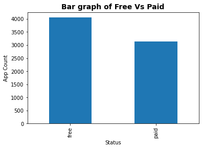

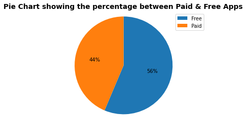

```python
#Q1

#bar plot of count
plt.title('Bar graph of Free Vs Paid', fontsize = 14,fontweight='bold')
app['Status'].value_counts().plot.bar()
plt.xlabel('Status')
plt.ylabel('App Count')
plt.show()

#pie chart showing percentage
sorted_counts = app['Status'].value_counts()
labels = 'Free', 'Paid'
plt.title("Pie Chart showing the percentage between Paid & Free Apps", fontsize = 14,fontweight='bold')
plt.pie(sorted_counts, startangle = 90,
        counterclock = False, autopct = '%1.f%%');
plt.axis('equal')
plt.legend(labels = labels);
plt.show();
```

The graphs in the previous slide indicate that Free Apps occupy more space than the Paid Apps by 56% of the whole App Store,having nearly 4000 Free Apps

#### Now Lets check the following about Genres/Categories:

- The Top 10 Genres
- The Least 10 Genres
- The Genres that are mostly rated

```
There's is total of 23 Genres
```

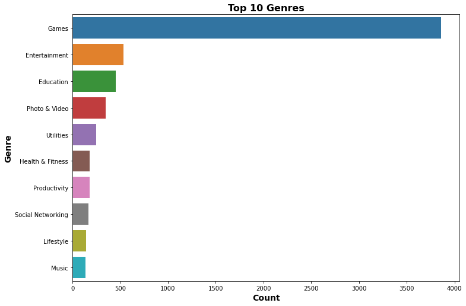

```python
#Q2

print('There\'s is total of {} Genres'.format(len(app.prime_genre.value_counts().index)))
app_genre = app.groupby(['prime_genre'])[['name']].count().reset_index().sort_values('name',ascending=False)
app_genre.columns = ['prime_genre','count']

#bar chart for top 10 genres
top_genres = app_genre.head(10)
plt.figure(figsize=[ 11.69, 8.27])
plt.title('Top 10 Genres', fontsize = 16,fontweight='bold')
sns.barplot(y = 'prime_genre',x = 'count', data=top_genres)
plt.xlabel('Count', fontsize = 14,fontweight='bold');
plt.ylabel('Genre',fontsize = 14,fontweight='bold');
plt.show()
```

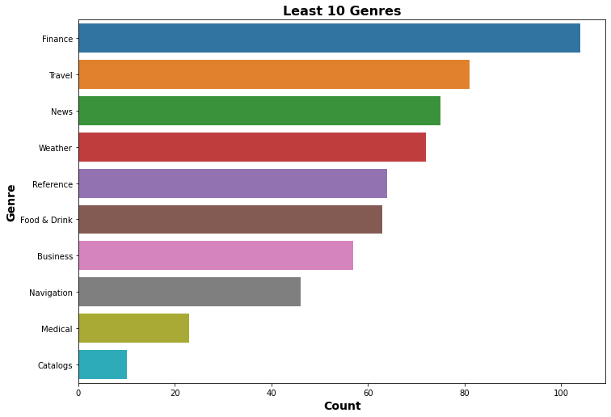

```python
#Q3

#bar chart for top 10 genres
plt.figure(figsize=[ 11.69, 8.27])
plt.title('Least 10 Genres', fontsize = 16,fontweight='bold')
least_genres = app_genre.tail(10)
sns.barplot(y = 'prime_genre',x = 'count', data=least_genres);
plt.xlabel('Count', fontsize = 14,fontweight='bold');
plt.ylabel('Genre', fontsize = 14,fontweight='bold');
plt.show();
```

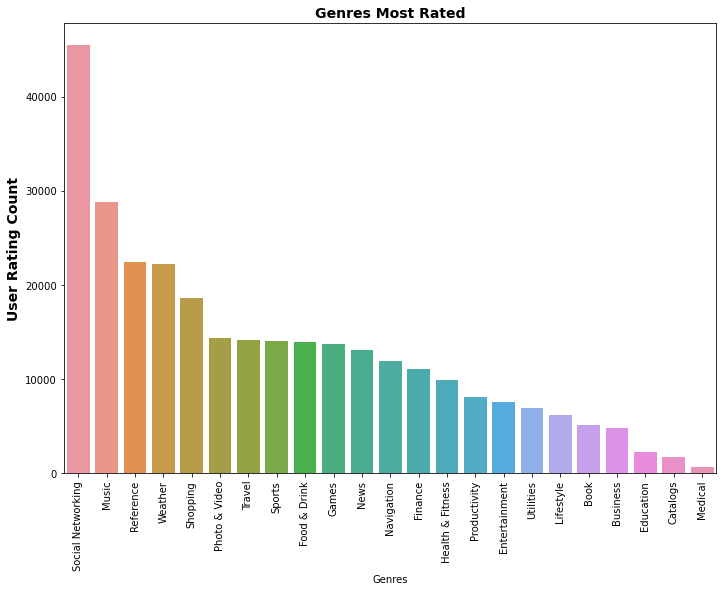

```python
#Q4

category = list(app.prime_genre.unique())
user_rating_count = []

for i in category:
    user_rating_count.append(app[app.prime_genre == i].rating_count_tot.mean())
rating_count = pd.DataFrame({'category':category,'user_rating_count':user_rating_count})
new_index = rating_count['user_rating_count'].sort_values(ascending=False).index.values
count = rating_count.reindex(new_index)


plt.figure(figsize=[ 11.69, 8.27])
sns.barplot(x=count['category'], y=count['user_rating_count'])
plt.xticks(rotation= 90)
plt.xlabel('Genres');
plt.ylabel('User Rating Count', fontsize = 14,fontweight='bold');
plt.title('Genres Most Rated',fontsize = 14,fontweight='bold');
plt.show()
```

#### Now Lets check the following:

All statics are dated till 2017

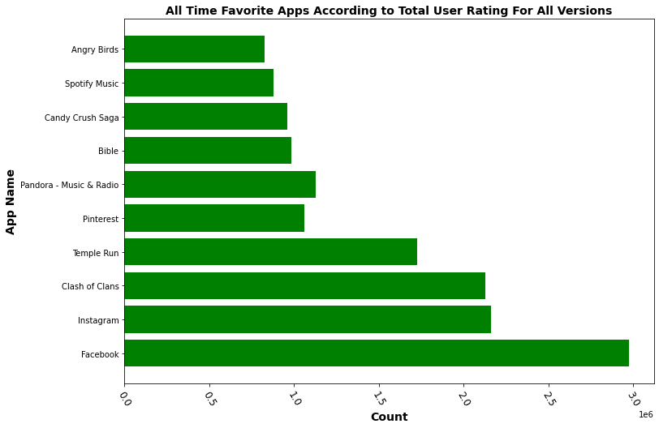

```python
#Q5

#all time favorite apps bar chart
app["fav_tot"] = app["rating_count_tot"] * app["user_rating"]
fav_app_tot = app.sort_values("fav_tot", ascending=False)
fav_app_tot_subset = fav_app_tot[:10]
plt.figure(figsize=[ 11.69, 8.27])
plt.title('All Time Favorite Apps According to Total User Rating For All Versions',fontsize = 14,fontweight='bold')
plt.barh(fav_app_tot_subset.name, fav_app_tot_subset.rating_count_tot,color='green');
plt.xticks(rotation=(-60), fontsize=12);
plt.xlabel('Count', fontsize = 14,fontweight='bold');
plt.ylabel('App Name', fontsize = 14,fontweight='bold');
```

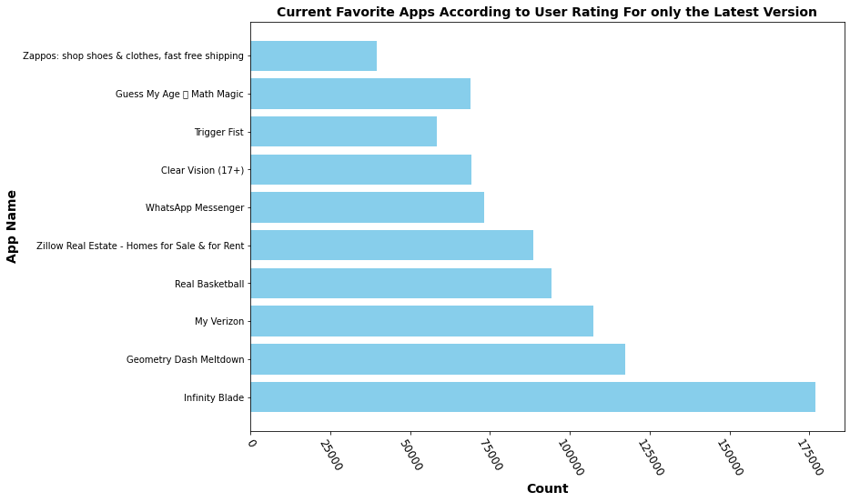

```python
#Q6

#current favorite apps bar chart
app["fav_ver"] = app["rating_count_ver"] * app["user_rating_ver"]
fav_app_ver = app.sort_values("fav_ver", ascending=False)
plt.figure(figsize=[ 11.69, 8.27])
fav_app_ver_subset = fav_app_ver[:10]
plt.title('Current Favorite Apps According to User Rating For only the Latest Version',fontsize = 14,fontweight='bold')
plt.barh(fav_app_ver_subset.name, fav_app_ver_subset.rating_count_ver,color='skyblue');
plt.xticks(rotation=(-60), fontsize=12);
plt.xlabel('Count',fontsize = 14,fontweight='bold');
plt.ylabel('App Name',fontsize = 14,fontweight='bold');
```

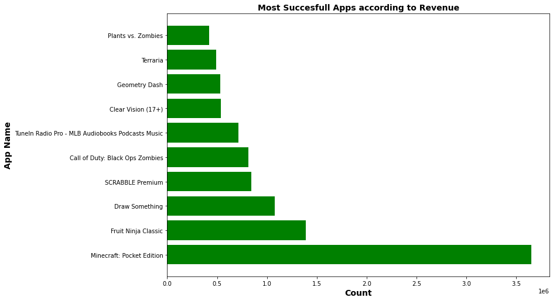

```python
#Q7

#Most Succesfull Apps according to Revenue bar chart
app['revenue'] = app.rating_count_tot * app.price
apps_revenue = app.sort_values("revenue", ascending=False)
subset_app_business = apps_revenue[:10]

plt.figure(figsize=[ 11.69, 8.27])
plt.title('Most Succesfull Apps according to Revenue',fontsize = 14,fontweight='bold');
plt.barh(subset_app_business.name, subset_app_business.revenue,color='green');
plt.xlabel('Count', fontsize = 14,fontweight='bold');
plt.ylabel('App Name', fontsize = 14,fontweight='bold');
```

Let's see the percentage of Paid Apps Vs. Free Apps in popular genres

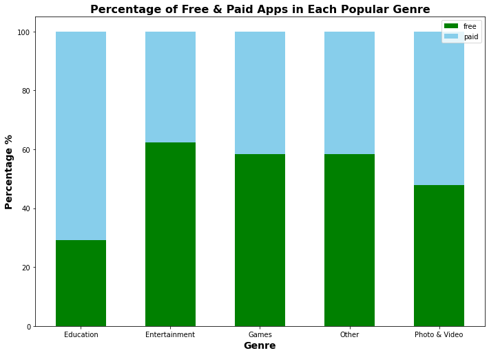

```python
#Q8

free = app[app.price==0].broad_genre.value_counts().sort_index().to_frame()
paid = app[app.price>0].broad_genre.value_counts().sort_index().to_frame()
total = app.broad_genre.value_counts().sort_index().to_frame()
free.columns=['free']
paid.columns=['paid']
total.columns=['total']
dist = free.join(paid).join(total)
dist ['paid_per'] = dist.paid*100/dist.total
dist ['free_per'] = dist.free*100/dist.total

list_free= dist.free_per.tolist()
tuple_free = tuple(list_free)
tuple_paidapps = tuple(dist.paid_per.tolist())

plt.figure(figsize=[ 11.69, 8.27])
N=5
ind = np.arange(N)    # the x locations for the groups
width =0.56   # the width of the bars: can also be len(x) sequence

plt.title("Percentage of Free & Paid Apps in Each Popular Genre", fontsize = 16,fontweight='bold')
plt.xlabel('Genre',fontsize = 14,fontweight='bold')
plt.ylabel('Percentage %',fontsize = 14,fontweight='bold')
p1 = plt.bar(ind, tuple_free, width, color='green')
p2 = plt.bar(ind, tuple_paidapps, width,bottom=tuple_free,color='skyblue')
plt.xticks(ind,tuple(dist.index.tolist() ))
plt.legend((p1[0], p2[0]), ('free', 'paid'))
plt.show()
# for pie chart
pies = dist[['free_per','paid_per']]
pies.columns=['free %','paid %']

plt.show()
```

### Let's see if Paid Apps are worth it ; according to user rating

In the next graph we will see that most apps in some categories are worth paying for, like in Gaming and Photo&Video

```python
l = app.prime_genre.value_counts().index[:4]

def catag(x):
    if x in l:
        return x
    else:
        return "Other"


app['broad_genre'] = app.prime_genre.apply(lambda x: catag(x))

app.drop(labels = ['broad_genre'], axis = 1)

data = pd.DataFrame(app['broad_genre'].value_counts())

data.sort_index()

free  = app[app['price'] == 0].broad_genre.value_counts().to_frame(name = 'free').sort_index()

paid = app[app['price']!= 0].broad_genre.value_counts().to_frame(name =  'paid').sort_index()
```

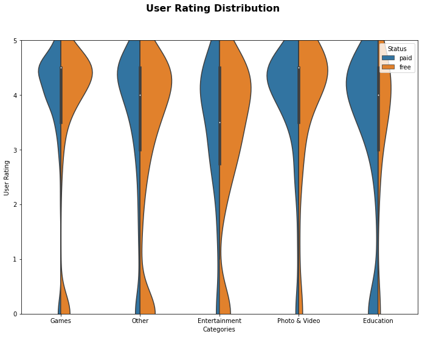

```python
#Q9

plt.figure(figsize=[ 11.69, 8.27])
plt.ylim(0,5)
sns.violinplot(data = app, y = 'user_rating', x = 'broad_genre', hue = 'Status', split = True, scale = 'count' )
plt.style.use("fast")
plt.xlabel('Categories');
plt.ylabel('User Rating');
plt.suptitle('User Rating Distribution', fontsize=16, fontweight='bold');
plt.show()
```

In the past slide, I was trying to check if Paid Apps received better rating according to users and unexpectedly, some Genres proved that their paid apps were perceived better by users. Apperently Paid apps in Photo & Video has a mean of 4.5 rating, which means they perform better than Free apps in these sections

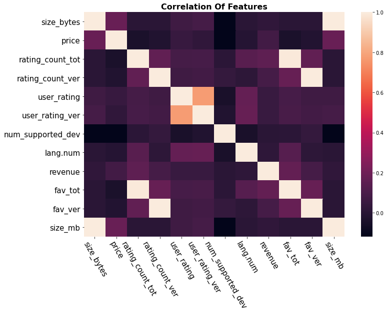

```python
#Q10

corr_apps = app.corr()
corr_apps["rating_count_tot"].sort_values(ascending=False)


plt.figure(figsize=[ 11.69, 8.27])
plt.title("Correlation Of Features", fontsize=16 ,fontweight = 'bold')
sns.heatmap(corr_apps)
plt.xticks(rotation=(-60), fontsize=15)
plt.yticks(fontsize=15)
plt.show()
```

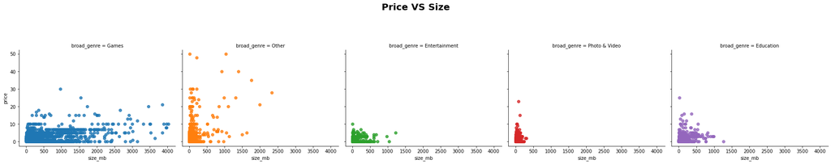

```python
#Q11
paid_apps_desc = app[app['price'] <50];
sns.lmplot(data = paid_apps_desc, x = 'size_mb', y = 'price', col = 'broad_genre',scatter = True,fit_reg = False, hue  = 'broad_genre');
plt.suptitle('Price VS Size', fontsize=20, fontweight='bold');
plt.subplots_adjust(top=0.7);
plt.show();
```

#### Thank You,

Omar Zazaa

> Once you're ready to finish your presentation, check your output by using nbconvert to export the notebook and set up a server for the slides. From the terminal or command line, use the following expression:

> > `jupyter nbconvert <file_name>.ipynb --to slides --post serve --template output_toggle`

> This should open a tab in your web browser where you can scroll through your presentation. Sub-slides can be accessed by pressing 'down' when viewing its parent slide. Make sure you remove all of the quote-formatted guide notes like this one before you finish your presentation!